# A3: Incarceration

### Introduction

In this analysis, I want to examine how prison trends and demographic proportions vary by urbanicity as it is part of the broader issues of crime and incarceration in the US. Urbanicity in this dataset refers to the classification of counties into urban, suburban, small/mid, and rural areas based on population density and other factors. As each of these types of areas face unique social, economic, and infrastructural challenges that influence crime rates and incarceration, examining how prison rates differ across these categories will allow us to gain insight into the underlying causes of crime and the effectiveness of the criminal justice system in different contexts.

### Summary Information

The maximum proportion of the population of a US county in prison over all the years which the dataset spans is 0.3378378, in McPherson County NE, in 2006.

When we distinguish between the urbancity of each county in the dataset we get that the maximum proportion of the population of a US county in prison is:

- 0.3378378, in McPherson County NE, in 2006, for rural areas
- 0.04332694, in Crockett County, NE, in 1983 for small/mid areas
- 0.03642545,in Fayette County, TN, in 1983, for suburban areas
- 0.01759245 in Baltimore, ME, in 1999, for urban areas

These numbers demonstrate how much the proportion of the population in prison can differ per the urbancity of an identified area. Overall, the proportion of the population in prison vs the broader proportion has a mean of 0.003392925 and a median of 0.002730052.

### The Dataset

The dataset, “U.S. Prison Population by County and State,” was collected by the Vera Institute of Justice. It was generated using data collected primarily by the U.S. Department of Justice Bureau of Justice Statistics and was done so in order to provide a comprehensive overview of US prison populations to increase transparency in the criminal justice system, support policy-making and reform efforts, facilitate research into incarceration trends, their impacts, and further disparities that exist within this system. There are 153811 observations, that span from 1970 to 2018, and 36 features in this dataset.

Some ethical considerations to keep in mind while looking at this dataset, is the biases that both exist within the broader criminal justice system, as well as specifically in the reporting of this information to government agencies, off which this dataset is based off of and by extension would be reflective of. Thus, it would be important to ethically consider how one would approach this data in the broader historical context of incarceration in the US and especially its disproportionate impact on racial minorities to ensure that further analysis does not perpetuate existing biases or reinforce systemic inequalities.

### Trends Over Time Chart

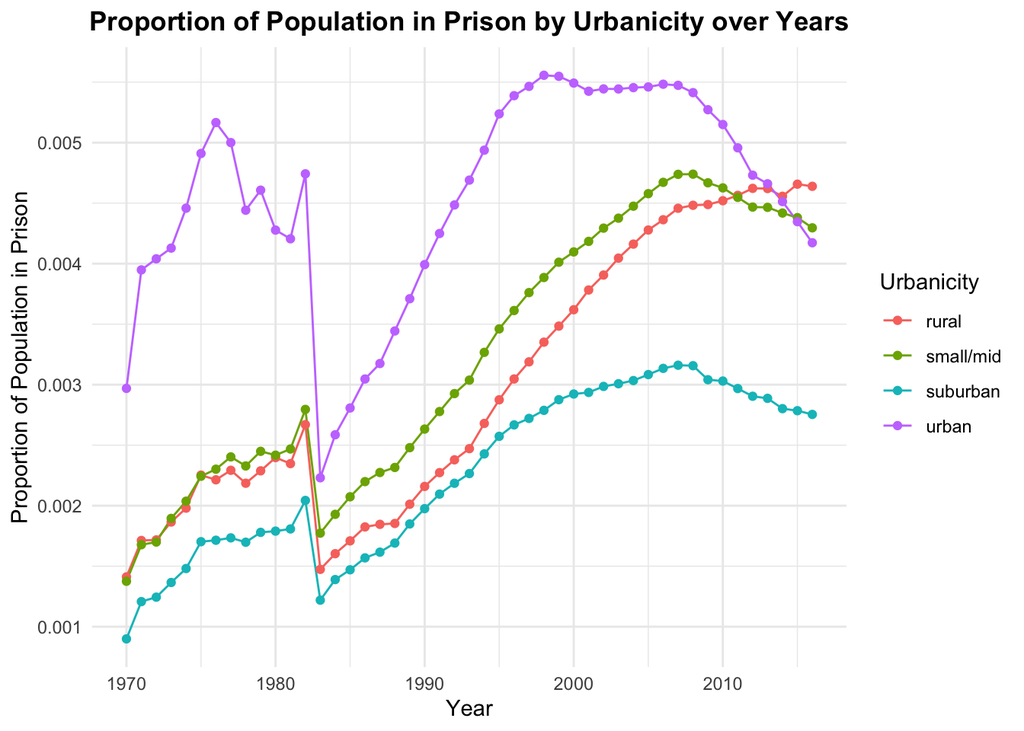

### Variable Comparison Chart

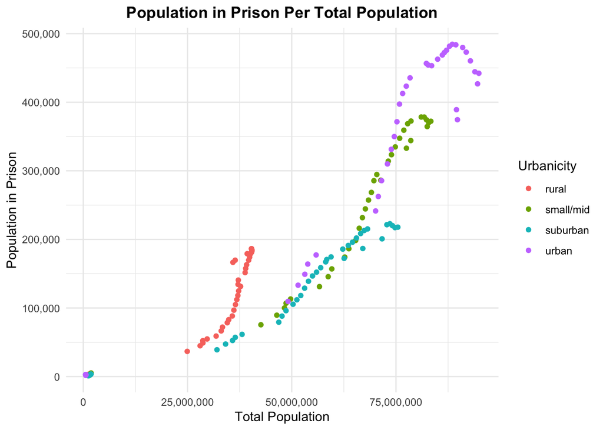

The scatter plot above illustrates the relationship between the total population and the prison population across different urbanicities (urban, suburban, rural, and small/mid). Each point on the graph represents a specific urbanicity category for a given year, color-coded for easy differentiation. The x-axis denotes the total population, while the y-axis represents the population in prison. The scatter plot was chosen to reveal the correlation between the total population and the prison population across different urbanicity categories, as it visualizes how these two variables related to each other and allows for an easy comparison between urbancity categories, further distinguished by color coding. Some insights that can be drawn from this chart is that there is a clear positive correlation between the total population and the prison population for all urbanicities, with this peaking for urban areas.

### Map

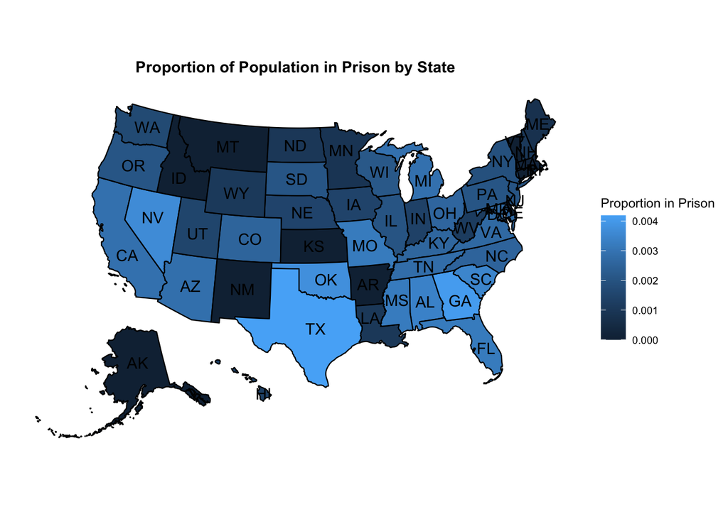

The map visualizes the proportion of the population in prison by state using a continuous color scale. States with higher proportions of their population in prison are represented in lighter shades, while states with lower proportions are in darker shades. By mapping this data it provides a clear visual representation of the spatial distribution of prison populations across states. For example, Texas seems to have a relativetly high proption of its population in prison compared to other states.